# Homework 4-5

## 7) Mont

### Task 1

The data is imported and necessary manipulations are made.  
Let us have a look at the first 6 rows of each column.

```r
data_48740784 <- data_manip("48740784", normal = F)
head(data_48740784)
```

```
##    event_date  price sold_count visit_count basket_count favored_count
## 1: 2020-05-25 833.32          0          18            0             1
## 2: 2020-05-26 833.32          0          18            0             1
## 3: 2020-05-27 833.32          0          18            0             1
## 4: 2020-05-28 833.32          0          18            0             1
## 5: 2020-05-29 833.32          0          18            0             1
## 6: 2020-05-30 833.32          0          18            0             1
##    category_sold category_visits category_basket category_favored
## 1:            15            1002          248050             6866
## 2:            14            1091          257980             7201
## 3:            16            1036          232193             6331
## 4:            17             846          213727             5708
## 5:            21             932          207028             5482
## 6:            15             778          200893             5275
##    category_brand_sold ty_visits discount
## 1:               33713 116610408        0
## 2:               32590 116586887        0
## 3:               34837 116633930        0
## 4:               35960 116657451        0
## 5:               40453 116751537        0
## 6:               33713 116610408        0
```

The first step will be to apply daily decomposition. From the project report, it is obvious that the sales variance does not rise with time. As a result, the decomposition method should be additive.

```r
decomp_48740784 <- decomp(data_48740784, 7)
```

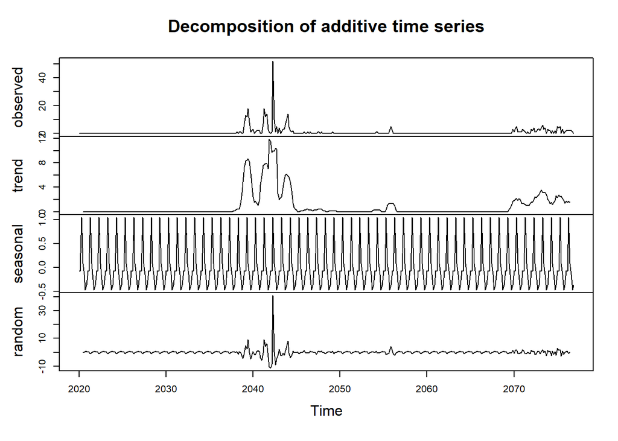

```
##
## #######################
## # KPSS Unit Root Test #
## #######################
##
## Test is of type: mu with 5 lags.
##
## Value of test-statistic is: 0.0085
##
## Critical value for a significance level of:
##                 10pct  5pct 2.5pct  1pct
## critical values 0.347 0.463  0.574 0.739
```

The results from unit root test belongs to the random component of decomposition. Since its significance value is lower than the significance levels, the null hypothesis is failed to be rejected. The null hypothesis is that the data is stationary. So, the data is stationary.

As you can observe, for some seasons such as Summer of 2020, January of 2021 or Spring of 2021 there are not any sales at all, which leads us there may be a kind of a seasonality or there may be a different effects such as price. To understand what affects our daily sales, it is necessary that to control over correlations between different properties.

Because the data does not cover sales from the previous two years, weekly and monthly decompositions are not possible. There are not enough time periods for different kind of composition. As a result, an error message is generated by this type of decomposition.

Now, the autocorrelation and partial autocorrelation graphs will be analyzed.

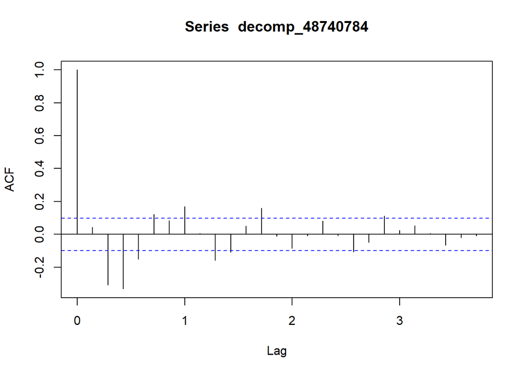

```r
acf(decomp_48740784, na.action = na.pass)
```

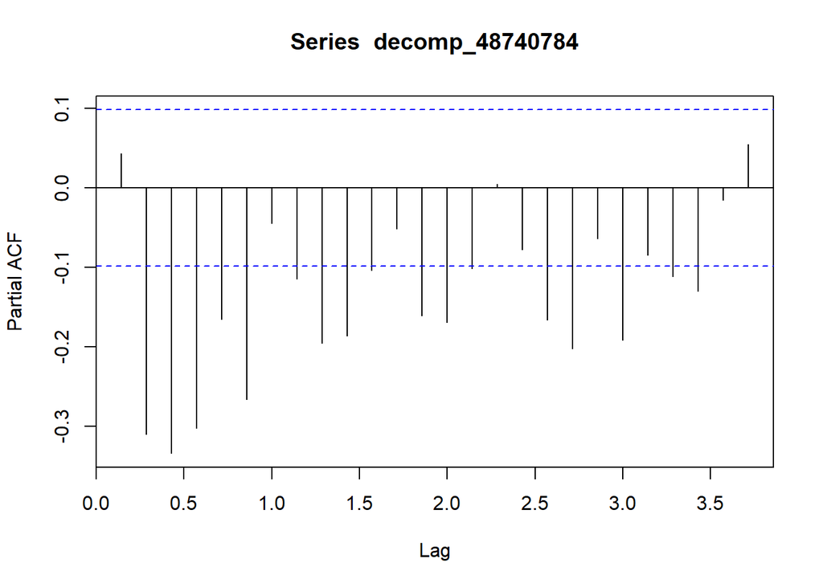

```r
pacf(decomp_48740784, na.action = na.pass)
```

### Task 2

According to the plots above, ARIMA (1,0,0) can be applied as a baseline model.

```r
model1 <- arima(decomp_48740784, order = c(1,0,0))
summary(model1)
```

```
##
## Call:
## arima(x = decomp_48740784, order = c(1, 0, 0))
##
## Coefficients:
##          ar1  intercept
##       0.0431     0.0013
## s.e.  0.0503     0.1404
##
## sigma^2 estimated as 7.097:  log likelihood = -942.72,  aic = 1891.43
##
## Training set error measures:
##                        ME     RMSE       MAE      MPE     MAPE      MASE
## Training set 3.129096e-05 2.663994 0.8908194 6.388256 182.2824 0.7377994
##                    ACF1
## Training set 0.01344526
```

Since lag-4 variable has a significant partial autocorrelation after the biggest one in the lag-3, ARIMA (0,0,4) can also be tried.

```r
model2 <- arima(decomp_48740784, order = c(0,0,4))
summary(model2)
```

```
##
## Call:
## arima(x = decomp_48740784, order = c(0, 0, 4))
##
## Coefficients:
##           ma1      ma2      ma3     ma4  intercept
##       -0.6873  -0.6180  -0.1070  0.4123      0e+00
## s.e.   0.0624   0.0857   0.0896  0.0642      6e-04
##
## sigma^2 estimated as 4.267:  log likelihood = -846.62,  aic = 1705.24
##
## Training set error measures:
##                       ME     RMSE       MAE      MPE     MAPE      MASE
## Training set 0.009097396 2.065695 0.8381743 810.9812 1023.193 0.6941974
##                  ACF1
## Training set 0.152897
```

Lastly, combining these two approaches may lead us to the better one. The ARIMA model (1,0,4) is below.

```r
model3 <- arima(decomp_48740784, order = c(1,0,4))
summary(model3)
```

```
##
## Call:
## arima(x = decomp_48740784, order = c(1, 0, 4))
##
## Coefficients:
##          ar1      ma1      ma2     ma3     ma4  intercept
##       0.5165  -1.0891  -0.3018  0.0485  0.3424      0e+00
## s.e.  0.0679   0.0639   0.0900  0.1063  0.0580      4e-04
##
## sigma^2 estimated as 3.831:  log likelihood = -826.04,  aic = 1666.08
##
## Training set error measures:
##                      ME     RMSE       MAE      MPE     MAPE      MASE
## Training set 0.01181209 1.957373 0.7599779 643.1919 731.4935 0.6294331
##                    ACF1
## Training set 0.03925311
```

The lowest AIC value belongs to ARIMA (1,0,4) model. Therefore, this model can be chosen as the last model.

### Task 3

Most variables in the project are not independent (basket count, favored count, category sold). As a result, utilizing numerous regressors in the model isn’t recommended. There will be a multicollinearity issue.

Now, the correlation matrix will be observed.

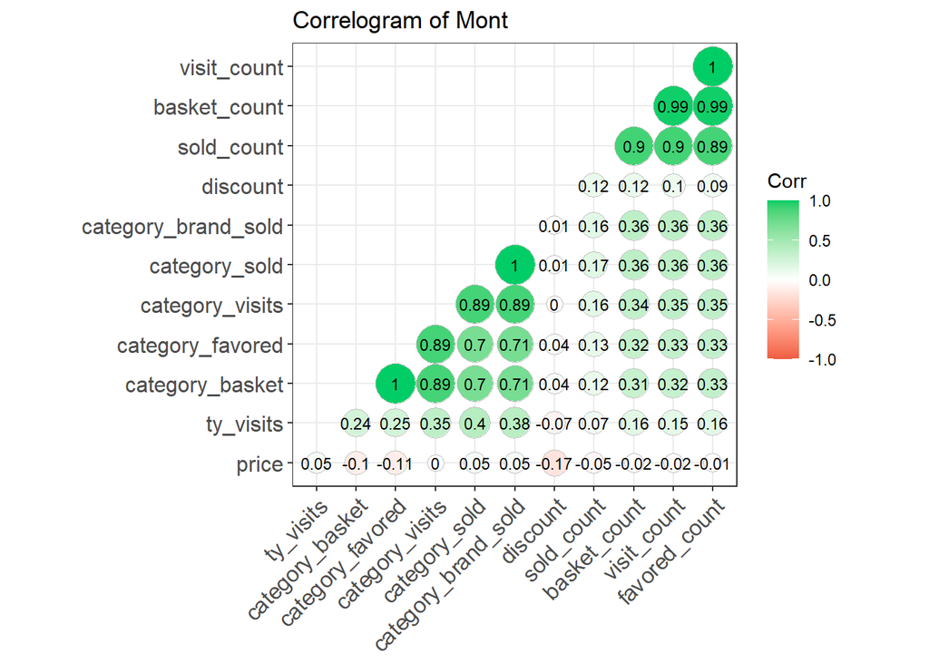

```r
cor_plot(data_48740784, "Mont")
```

The number of sales have high correlation with basket_count, and visit_count. Since the features are scaled differently, they should be normalized.

### Task 4

```r
decomp_48740784_norm <- data_manip("48740784", normal = T)
model4 <- arima(decomp_48740784, order = c(1,0,4), xreg = cbind(decomp_48740784_norm$basket_count))
summary(model4)
```

```
##
## Call:
## arima(x = decomp_48740784, order = c(1, 0, 4), xreg = cbind(decomp_48740784_norm$basket_count))
##
## Coefficients:
##          ar1      ma1      ma2      ma3     ma4  intercept
##       0.9712  -0.5373  -0.0453  -0.1663  0.0132     0.0407
## s.e.  0.0147   0.0557   0.0632   0.0640  0.0594     0.7010
##       cbind(decomp_48740784_norm$basket_count)
##                                         3.0028
## s.e.                                    0.1333
##
## sigma^2 estimated as 2.641:  log likelihood = -749.01,  aic = 1514.02
##
## Training set error measures:
##                       ME     RMSE      MAE       MPE     MAPE      MASE
## Training set -0.01247259 1.625112 0.881014 -985.4826 1492.602 0.7296783
##                     ACF1
## Training set 0.001403451
```

It can be said that AIC value decreased, which is preferred.

Now, visit_count will be added, instead of basket_count

```r
model5 <- arima(decomp_48740784, order = c(1,0,4), xreg = cbind(decomp_48740784_norm$visit_count))
summary(model5)
```

```
##
## Call:
## arima(x = decomp_48740784, order = c(1, 0, 4), xreg = cbind(decomp_48740784_norm$visit_count))
##
## Coefficients:
##          ar1      ma1      ma2      ma3     ma4  intercept
##       0.9701  -0.5179  -0.0541  -0.1672  0.0134     0.0256
## s.e.  0.0153   0.0557   0.0619   0.0628  0.0593     0.7031
##       cbind(decomp_48740784_norm$visit_count)
##                                        3.0254
## s.e.                                   0.1323
##
## sigma^2 estimated as 2.652:  log likelihood = -749.86,  aic = 1515.72
##
## Training set error measures:
##                       ME     RMSE       MAE       MPE     MAPE     MASE
## Training set -0.01222348 1.628625 0.8999529 -1011.278 1529.505 0.745364
##                     ACF1
## Training set 0.001303653
```

Now, forecasts for the last week will be made and plotted to better analysis.

```r
comparison_48740784 <- forecast_func(data = data_48740784$sold_count, ar_order = c(1,0,4), reg_matrix = cbind(data_48740784$visit_count))
```

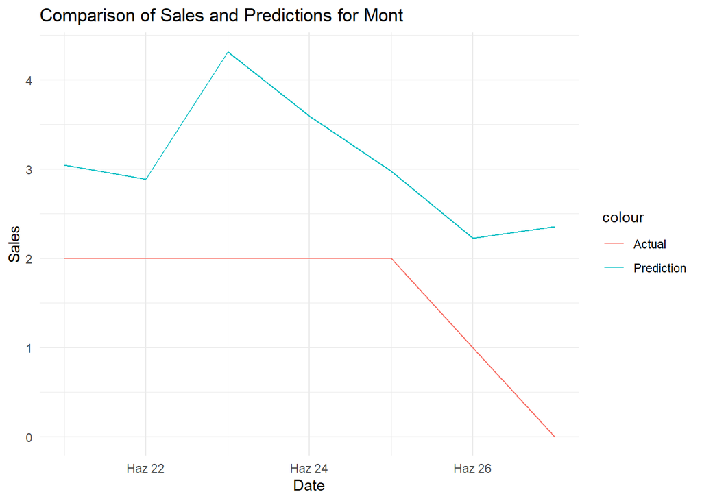

```r
comparison_48740784 <- data.table(cbind(data_48740784$event_date[(nrow(data_48740784)-6):nrow(data_48740784)], comparison_48740784))
colnames(comparison_48740784) <- c("event_date", "Actual", "Prediction")
plotting(comparison_48740784,product_name = "Mont", col = "",num =2)
```

For a prediction model that predicts different numbers between 0 and 6, accuracy of our model seems fair enough, which leads us to calculations of the other products.

## 8) Bikini Üstü (1)

### Task 1

The data is imported and the appropriate adjustments are done.  
Let’s examine the top six rows of each column.

```r
data_73318567 <- data_manip("73318567", normal = F)
head(data_48740784)
```

[output not shown]

The first stage will be to decompose on a daily basis. It is clear from the project report that the sales variation does not increase over time. As a result, the method of decomposition must be additive.

```r
decomp_73318567 <- decomp(data_73318567, 7)
```

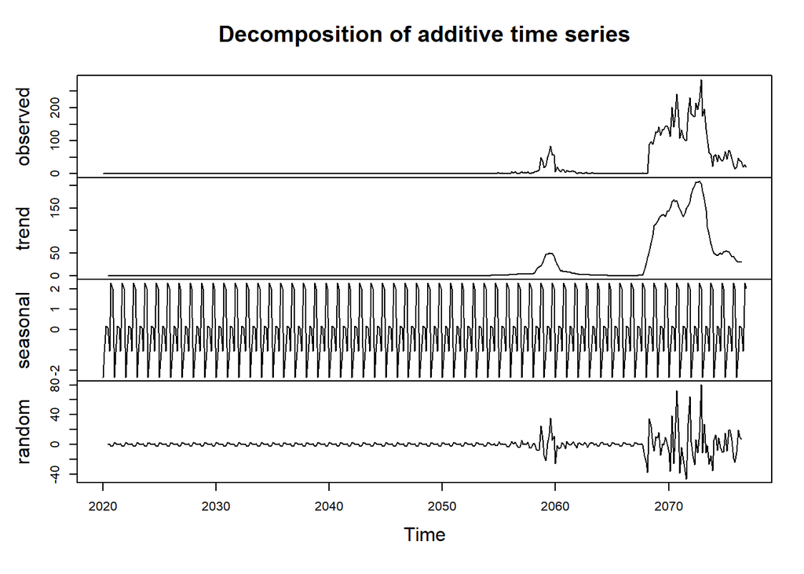

```
##
## #######################
## # KPSS Unit Root Test #
## #######################
##
## Test is of type: mu with 5 lags.
##
## Value of test-statistic is: 0.0104
##
## Critical value for a significance level of:
##                 10pct  5pct 2.5pct  1pct
## critical values 0.347 0.463  0.574 0.739
```

The random component of decomposition includes the results of the unit root test. The null hypothesis is not rejected since its significance value is less than the significance thresholds. The data is stationary, according to the null hypothesis.

As you can observe from the plot, the sales over time are very different from each other. There are not any sales nearly until February 2021. The reason behind that could be the bikini top is not for the sale in that time frame. After February 2021 the sales are increased and decreased instantly, and again there are no sales. The reason behind that also could be the same. Later, when the summer hits, the sales increased very quick which may be occurred because of the change in price or increased stocks in our product. Weekly and monthly decomposition cannot be applied because the data do not include sales happened in 2 years. There are less than two periods. Therefore, this type of decomposition brings an error message.

The graphs of autocorrelation and partial autocorrelation will now be examined.

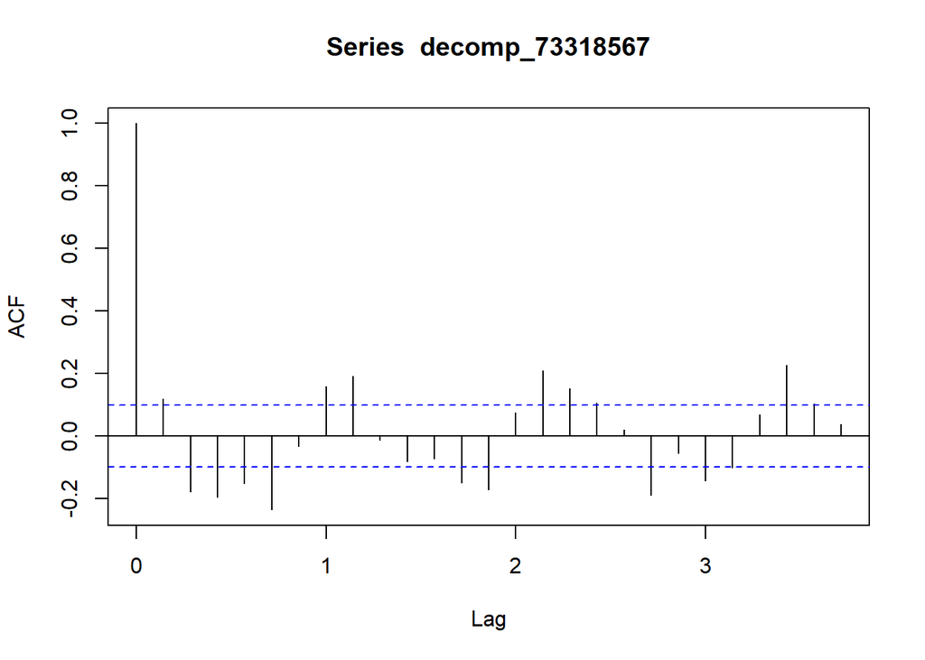

```r
acf(decomp_73318567, na.action = na.pass)
```

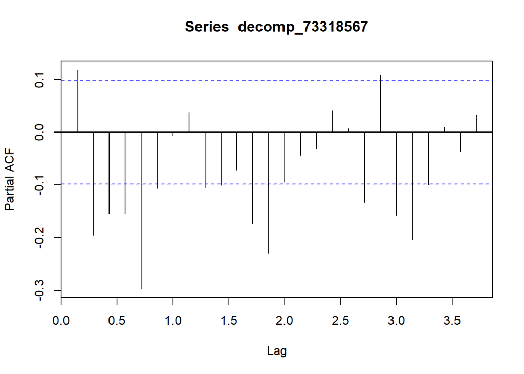

```r
pacf(decomp_73318567, na.action = na.pass)
```

### Task 2

According to the plots above, ARIMA (1,0,0) can be applied as a baseline model.

```r
model1 <- arima(decomp_73318567, order = c(1,0,0))
summary(model1)
```

```
##
## Call:
## arima(x = decomp_73318567, order = c(1, 0, 0))
##
## Coefficients:
##          ar1  intercept
##       0.1178     0.0388
## s.e.  0.0500     0.5990
##
## sigma^2 estimated as 109.8:  log likelihood = -1480.96,  aic = 2967.92
##
## Training set error measures:
##                        ME    RMSE      MAE    MPE     MAPE      MASE     ACF1
## Training set 0.0009533427 10.4792 4.583608 136.85 138.4337 0.7408935 0.023321
```

Since lag-5 variable has a significant autocorrelation, ARIMA (5,0,0) can also be tried.

```r
model2 <- arima(decomp_73318567, order = c(5,0,0))
summary(model2)
```

```
##
## Call:
## arima(x = decomp_73318567, order = c(5, 0, 0))
##
## Coefficients:
##          ar1      ar2      ar3      ar4      ar5  intercept
##       0.0389  -0.2421  -0.1975  -0.1325  -0.2993     0.0185
## s.e.  0.0481   0.0476   0.0482   0.0478   0.0483     0.2644
##
## sigma^2 estimated as 91.43:  log likelihood = -1445.33,  aic = 2904.65
##
## Training set error measures:
##                        ME     RMSE      MAE      MPE     MAPE      MASE
## Training set -0.001477023 9.562058 3.965705 166.4667 185.1378 0.6410158
##                     ACF1
## Training set -0.03199084
```

```r
model3 <- arima(decomp_73318567, order = c(0,0,5))
summary(model3)
```

```
##
## Call:
## arima(x = decomp_73318567, order = c(0, 0, 5))
##
## Coefficients:
##           ma1      ma2      ma3      ma4      ma5  intercept
##       -0.0802  -0.3475  -0.2691  -0.1259  -0.1773     0.0017
## s.e.   0.0493   0.0548   0.0581   0.0481   0.0619     0.0120
##
## sigma^2 estimated as 84.12:  log likelihood = -1430.96,  aic = 2875.92
##
## Training set error measures:
##                       ME     RMSE      MAE     MPE     MAPE      MASE
## Training set -0.05333884 9.171719 3.814444 122.369 148.3585 0.6165659
##                      ACF1
## Training set -0.004057043
```

Lastly, combining these two approaches may lead us to the better one. The ARIMA model (5,0,5) is below.

```r
model4 <- arima(decomp_73318567, order = c(5,0,5))
summary(model4)
```

```
##
## Call:
## arima(x = decomp_73318567, order = c(5, 0, 5))
##
## Coefficients:
##          ar1      ar2      ar3     ar4      ar5      ma1     ma2     ma3
##       0.2012  -0.3961  -0.4063  0.5749  -0.3816  -0.2994  0.0958  0.1195
## s.e.  0.1305   0.0628   0.0731  0.0739   0.0900   0.1421  0.0709  0.0661
##           ma4     ma5  intercept
##       -0.9243  0.0083     0.0017
## s.e.   0.0648  0.1369     0.0094
##
## sigma^2 estimated as 78.1:  log likelihood = -1419.5,  aic = 2862.99
##
## Training set error measures:
##                       ME     RMSE      MAE      MPE     MAPE      MASE
## Training set -0.06261232 8.837703 3.952581 178.4168 246.9922 0.6388944
##                       ACF1
## Training set -0.0002326932
```

The lowest AIC value belongs to ARIMA (5,0,5) model. Therefore, this model can be chosen as the last model.

### Task 3

Most variables in the project are not independent (basket count, favored count, category sold). As a result, utilizing numerous regressors in the model isn’t recommended because will be a multicollinearity issue.

Now, the correlation matrix will be observed.

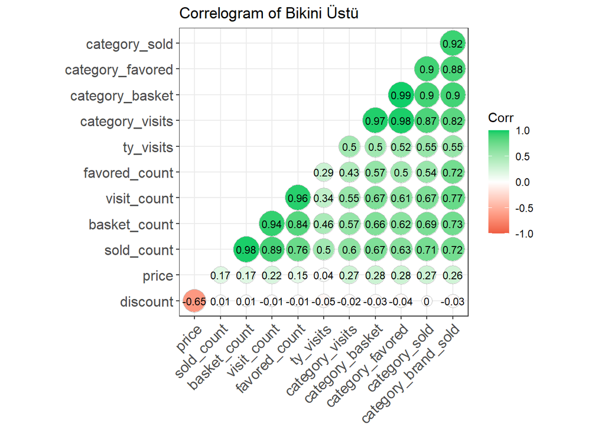

```r
cor_plot(data_73318567, "Bikini Üstü")
```

The number of sales have high correlation with basket_count, and visit_count. Since the features are scaled differently, they should be normalized.

### Task 4

```r
decomp_73318567_norm <- data_manip("48740784", normal = T)
model4 <- arima(decomp_73318567, order = c(5,0,5), xreg = cbind(decomp_73318567_norm$basket_count))
summary(model4)
```

```
##
## Call:
## arima(x = decomp_73318567, order = c(5, 0, 5), xreg = cbind(decomp_73318567_norm$basket_count))
##
## Coefficients:
##          ar1      ar2      ar3     ar4      ar5      ma1     ma2     ma3
##       0.1986  -0.3966  -0.4066  0.5734  -0.3798  -0.2967  0.0956  0.1192
## s.e.  0.1319   0.0647   0.0755  0.0747   0.0903   0.1434  0.0733  0.0686
##           ma4     ma5  intercept  cbind(decomp_73318567_norm$basket_count)
##       -0.9232  0.0052     0.0011                                    0.0098
## s.e.   0.0664  0.1372     0.0100                                    0.0568
##
## sigma^2 estimated as 78.1:  log likelihood = -1419.48,  aic = 2864.96
##
## Training set error measures:
##                       ME    RMSE      MAE      MPE     MAPE      MASE
## Training set -0.06147073 8.83758 3.957593 180.0479 256.0776 0.6397045
##                       ACF1
## Training set -0.0003076288
```

It can be said that AIC value is approximately same.

Now, visit_count will be added, instead of basket_count

```r
model5 <- arima(decomp_73318567, order = c(5,0,5), xreg = cbind(decomp_73318567_norm$visit_count))
summary(model5)
```

```
##
## Call:
## arima(x = decomp_73318567, order = c(5, 0, 5), xreg = cbind(decomp_73318567_norm$visit_count))
##
## Coefficients:
##          ar1      ar2      ar3     ar4      ar5      ma1     ma2     ma3
##       0.2012  -0.3959  -0.4065  0.5751  -0.3817  -0.2994  0.0957  0.1197
## s.e.  0.1304   0.0625   0.0727  0.0738   0.0900   0.1420  0.0705  0.0657
##           ma4     ma5  intercept  cbind(decomp_73318567_norm$visit_count)
##       -0.9244  0.0085     0.0013                                   0.0054
## s.e.   0.0645  0.1369     0.0101                                   0.0561
##
## sigma^2 estimated as 78.1:  log likelihood = -1419.49,  aic = 2864.98
##
## Training set error measures:
##                       ME     RMSE     MAE      MPE     MAPE      MASE
## Training set -0.06278932 8.837569 3.95562 179.6783 251.8685 0.6393856
##                      ACF1
## Training set -0.000224033
```

It has the same AIC value, compared to the model with basket_count Therefore, selecting one of them is enough.

Now, lastly, category_visits will be used as a regressor.

```r
model6 <- arima(decomp_73318567, order = c(5,0,5), xreg = cbind(decomp_73318567_norm$category_visits))
summary(model6)
```

```
##
## Call:
## arima(x = decomp_73318567, order = c(5, 0, 5), xreg = cbind(decomp_73318567_norm$category_visits))
##
## Coefficients:
##          ar1      ar2      ar3     ar4      ar5      ma1     ma2     ma3
##       0.2040  -0.3969  -0.4069  0.5751  -0.3849  -0.3037  0.0967  0.1196
## s.e.  0.1302   0.0625   0.0728  0.0738   0.0896   0.1421  0.0706  0.0658
##           ma4     ma5  intercept  cbind(decomp_73318567_norm$category_visits)
##       -0.9253  0.0127     0.0087                                      -0.0305
## s.e.   0.0646  0.1370     0.0132                                       0.0401
##
## sigma^2 estimated as 77.99:  log likelihood = -1419.21,  aic = 2864.42
##
## Training set error measures:
##                     ME    RMSE      MAE      MPE     MAPE      MASE
## Training set -0.151148 8.83104 3.997123 199.7453 274.4273 0.6460941
##                       ACF1
## Training set -0.0004395922
```

Now, forecasts for the last week will be made.

```r
comparison_73318567 <- forecast_func(data = data_73318567$sold_count, ar_order = c(5,0,5), reg_matrix = cbind(data_73318567$category_visits))
```

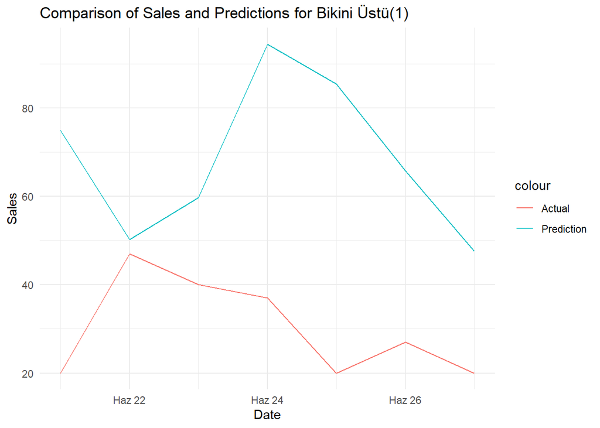

```r
comparison_73318567 <- data.table(cbind(data_73318567$event_date[(nrow(data_73318567)-6):nrow(data_73318567)], comparison_73318567))
colnames(comparison_73318567) <- c("event_date", "Actual", "Prediction")
plotting(comparison_73318567,product_name = "Bikini Üstü(1)", col = "",num =2)
```

The forecasts seems not good enough but it is valid for a prediction model that uses only AR and MA approaches. To provide more improvement for the model, it would be wise that using seasonalities because it is a seasonal product or using SARIMA or GAM models.

## 9) Tayt

### Task 1

The data is imported and necessary manipulations are made.  
Let us have a look at the first 6 rows of each column.

```r
data_31515569 <- data_manip("31515569", normal = F)
head(data_48740784)
```

[output not shown]

The first step will be a daily decomposition. The project report clearly shows that the sales variety does not rise over time. As a result, the breakdown process must be additive.

```r
decomp_31515569 <- decomp(data_31515569, 7)
```

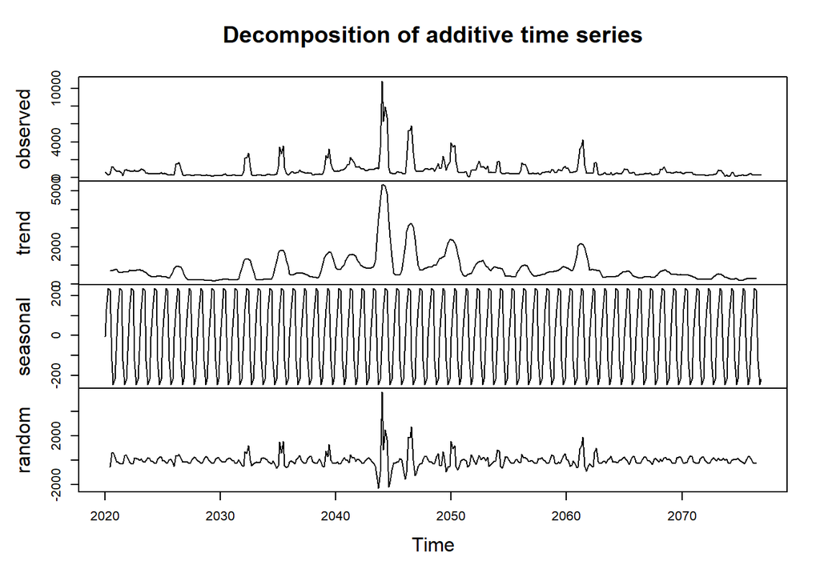

```
##
## #######################
## # KPSS Unit Root Test #
## #######################
##
## Test is of type: mu with 5 lags.
##
## Value of test-statistic is: 0.0074
##
## Critical value for a significance level of:
##                 10pct  5pct 2.5pct  1pct
## critical values 0.347 0.463  0.574 0.739
```

The random component of decomposition includes the results of the unit root test. The null hypothesis is not rejected since its significance value is less than the significance thresholds. The data is stationary, according to the null hypothesis. As a result, the data is static and stationary.

From the plot it can be observed that there are much variation in the series. The sales follows a general trend over time. However there are various instant increases in the sales like the one in the “Black Friday”. The reason behind that could be a decrease in price. The following calculations will helps us to reach whether this assumption is correct. In order to become a good prediction model, the model needs some regressors to predict next sales.

Weekly and monthly decompositions are not possible because the data does not include sales from the prior two years. There are insufficient time periods for various types of composing. As a result, this type of decomposition generates an error message.

Now, the autocorrelation and partial autocorrelation graphs will be analyzed.

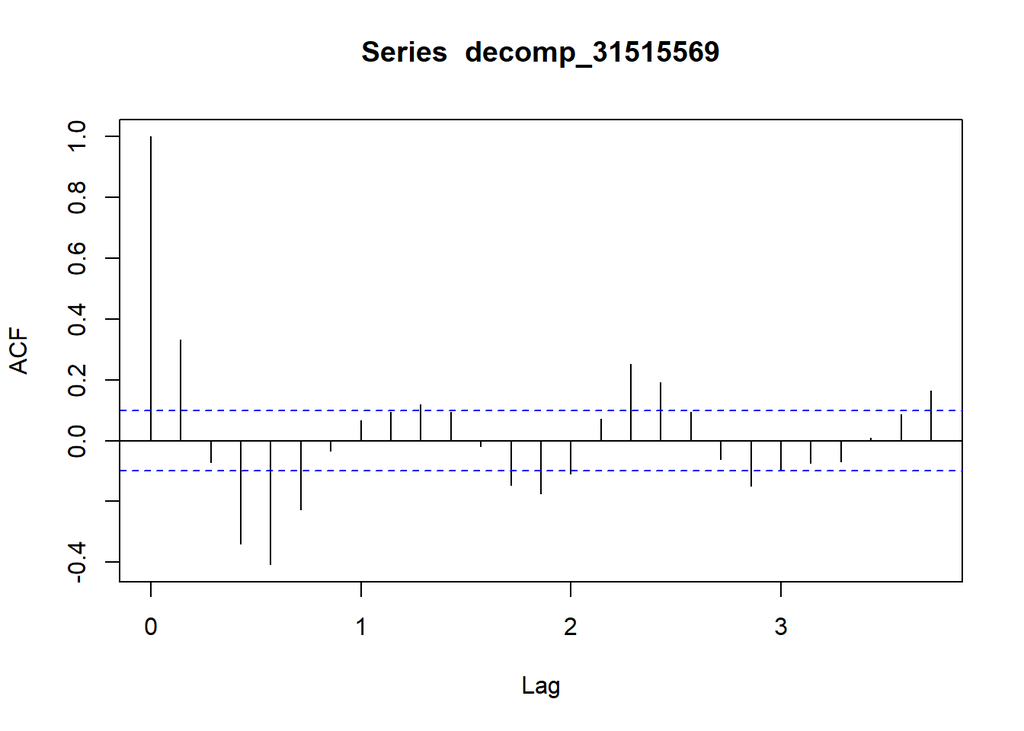

```r
acf(decomp_31515569, na.action = na.pass)
```

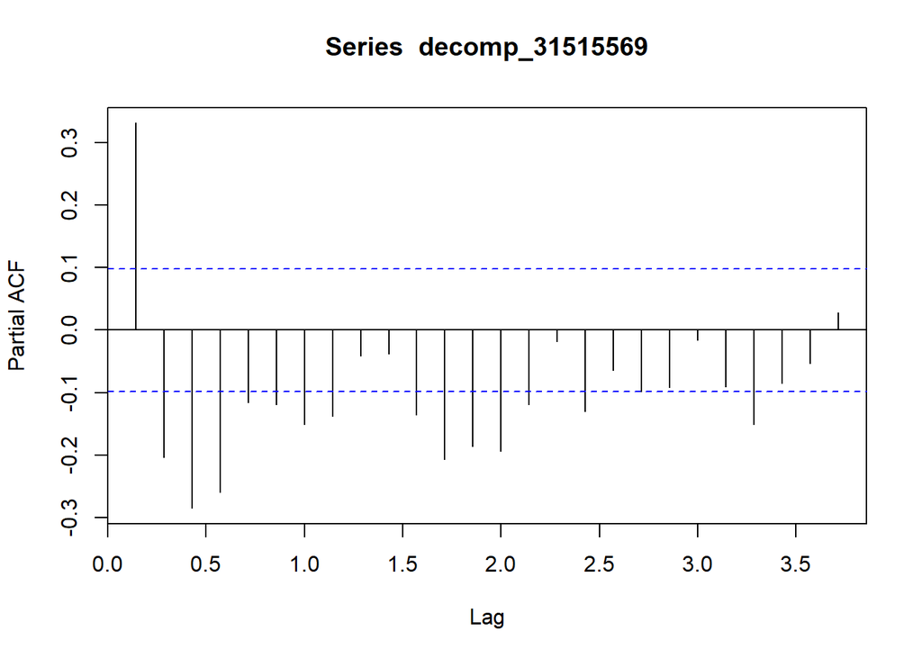

```r
pacf(decomp_31515569, na.action = na.pass)
```

You can see that lag-1 has a lot of autocorrelation and an exponential drop in this graph. The partial autocorrelation graph reveals a rapid decline after lag-1, with generally negative autocorrelation for the succeeding lags. Furthermore, the ACF plot looks like a sinus function. Seasonal autocorrelation is not seen in these graphs.

### Task 2

According to the plots above, ARIMA (1,0,0) can be applied as a baseline model.

```r
model1 <- arima(decomp_31515569, order = c(1,0,0))
summary(model1)
```

```
##
## Call:
## arima(x = decomp_31515569, order = c(1, 0, 0))
##
## Coefficients:
##          ar1  intercept
##       0.3314    -0.6102
## s.e.  0.0476    40.3561
##
## sigma^2 estimated as 286857:  log likelihood = -3027.07,  aic = 6060.13
##
## Training set error measures:
##                     ME     RMSE      MAE      MPE     MAPE      MASE       ACF1
## Training set 0.4661154 535.5908 290.1284 129.6814 163.4625 0.9149846 0.06772813
```

Since lag-4 variable has a significant autocorrelation, ARIMA (4,0,0) can also be tried.

```r
model2 <- arima(decomp_31515569, order = c(4,0,0))
summary(model2)
```

```
##
## Call:
## arima(x = decomp_31515569, order = c(4, 0, 0))
##
## Coefficients:
##          ar1      ar2      ar3      ar4  intercept
##       0.2672  -0.1142  -0.1971  -0.2600    -0.2653
## s.e.  0.0487   0.0496   0.0496   0.0487    18.8041
##
## sigma^2 estimated as 234876:  log likelihood = -2988.09,  aic = 5988.18
##
## Training set error measures:
##                     ME   RMSE      MAE      MPE     MAPE      MASE        ACF1
## Training set 0.8611098 484.64 260.1447 77.37513 146.6412 0.8204243 -0.03183378
```

Lastly, lag-4 variable has also significant partial autocorrelation. The model is below.

```r
model3 <- arima(decomp_31515569, order = c(0,0,4))
summary(model3)
```

```
##
## Call:
## arima(x = decomp_31515569, order = c(0, 0, 4))
##
## Coefficients:
##          ma1      ma2      ma3      ma4  intercept
##       0.0452  -0.3004  -0.4003  -0.3444     0.0502
## s.e.  0.0464   0.0459   0.0433   0.0514     0.6222
##
## sigma^2 estimated as 204227:  log likelihood = -2962.74,  aic = 5937.48
##
## Training set error measures:
##                    ME     RMSE      MAE      MPE     MAPE      MASE       ACF1
## Training set 1.676329 451.9153 237.7718 64.68362 99.17051 0.7498663 0.02782415
```

Lastly, combining these two approaches may lead us to the better one. The ARIMA model (4,0,4) is below.

```r
model4 <- arima(decomp_73318567, order = c(4,0,4))
summary(model4)
```

[output not shown]

### Task 3

The majority of the project’s variables are not independent (basket count, favored count, category sold). As a result, including several regressors in the model is not suggested due to the risk of multicollinearity.

Now, the correlation matrix will be observed.

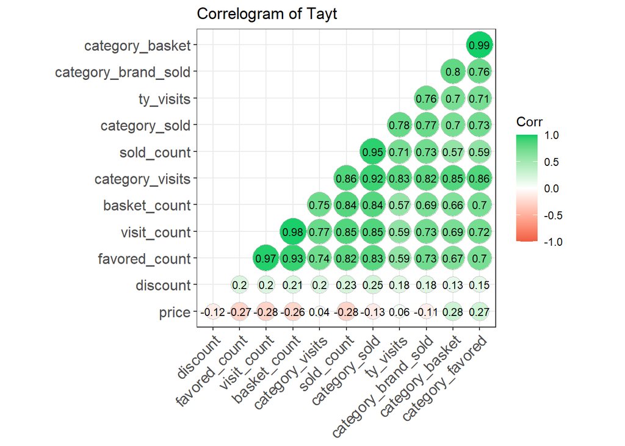

```r
cor_plot(data_31515569, "Tayt")
```

The number of sales have high correlation with category_sold, basket_count, and category_visit. Since the features are scaled differently, they should be normalized.

### Task 4

```r
decomp_31515569_norm <- data_manip("48740784", normal = T)
model4 <- arima(decomp_31515569, order = c(4,0,4), xreg = cbind(decomp_31515569_norm$category_sold))
summary(model4)
```

```
##
## Call:
## arima(x = decomp_31515569, order = c(4, 0, 4), xreg = cbind(decomp_31515569_norm$category_sold))
##
## Coefficients:
##           ar1     ar2    ar3      ar4     ma1      ma2      ma3     ma4
##       -0.0994  0.3676  0.233  -0.7185  0.0917  -0.7595  -0.7431  0.4125
## s.e.   0.0781  0.0717  0.043   0.0480  0.1139   0.0691   0.0769  0.1078
##       intercept  cbind(decomp_31515569_norm$category_sold)
##         -0.2890                                     2.4231
## s.e.     0.4096                                     1.7976
##
## sigma^2 estimated as 182452:  log likelihood = -2941.43,  aic = 5904.86
##
## Training set error measures:
##                    ME     RMSE      MAE      MPE     MAPE      MASE       ACF1
## Training set 3.155448 427.1436 241.5996 90.24507 149.6292 0.7619383 0.00998867
```

Now, basket_count will be added, instead of category_sold.

```r
model5 <- arima(decomp_31515569, order = c(4,0,4), xreg = cbind(decomp_31515569_norm$basket_count))
summary(model5)
```

```
##
## Call:
## arima(x = decomp_31515569, order = c(4, 0, 4), xreg = cbind(decomp_31515569_norm$basket_count))
##
## Coefficients:
##          ar1     ar2     ar3      ar4      ma1      ma2      ma3     ma4
##       0.0675  0.2203  0.1198  -0.5543  -0.0758  -0.5874  -0.5742  0.2375
## s.e.     NaN  0.1965     NaN      NaN      NaN   0.2170      NaN  0.0599
##       intercept  cbind(decomp_31515569_norm$basket_count)
##         -0.0345                                    1.2938
## s.e.     0.3599                                    2.0245
##
## sigma^2 estimated as 184615:  log likelihood = -2943.6,  aic = 5909.2
##
## Training set error measures:
##                    ME    RMSE      MAE      MPE     MAPE      MASE       ACF1
## Training set 0.310251 429.668 237.2994 76.64672 136.5645 0.7483766 0.00654275
```

It has higher AIC value, compared to the model with category_sold. Therefore, it will not be chosen as final model.

Now, lastly, category_visits will be used as a regressor.

```r
model6 <- arima(decomp_31515569, order = c(4,0,4), xreg = cbind(decomp_31515569_norm$category_visits))
summary(model6)
```

```
##
## Call:
## arima(x = decomp_31515569, order = c(4, 0, 4), xreg = cbind(decomp_31515569_norm$category_visits))
##
## Coefficients:
##          ar1     ar2      ar3      ar4     ma1      ma2      ma3      ma4
##       0.3277  1.0349  -0.2456  -0.1330  0.5252  -0.4885  -0.4190  -0.3137
## s.e.  0.1597  0.1553   0.1557   0.1317  0.1519   0.0989   0.1347   0.0633
##       intercept  cbind(decomp_31515569_norm$category_visits)
##         61.9256                                     936.1757
## s.e.   314.4361                                      53.8473
##
## sigma^2 estimated as 138074:  log likelihood = -2884.3,  aic = 5790.6
##
## Training set error measures:
##                     ME     RMSE      MAE      MPE     MAPE      MASE
## Training set -1.133787 371.5835 233.2479 107.1924 240.4663 0.7355992
##                       ACF1
## Training set -0.0006865144
```

Now, forecasts for the last week will be made.

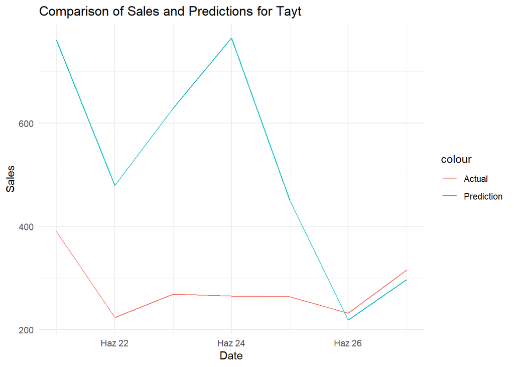

```r
comparison_31515569 <- forecast_func(data = data_31515569$sold_count, ar_order = c(4,0,4), reg_matrix = cbind(data_31515569$category_sold))
comparison_31515569 <- data.table(cbind(data_31515569$event_date[(nrow(data_31515569)-6):nrow(data_31515569)], comparison_31515569))
colnames(comparison_31515569) <- c("event_date", "Actual", "Prediction")
plotting(comparison_31515569,product_name = "Tayt", col = "",num =2)
```

The model are not very strong. However, usage of only one regressor and ARIMA model is really restrictive. As a result, the model is suitable.

**To reach the RMD file and the codes of this study, please [Click](https://bu-ie-360.github.io/spring21-yulucoban/files/Homework_4_5.Rmd).**